# Analyses: CORTEX-D-19-00912

December 2020

Install all **packages required to run** below code, if not already installed.

```r
if (!require("pacman")) install.packages("pacman")
pacman::p_load(janitor, cowplot, dplyr, readr, devtools, table1, MatchIt, descr, car, kableExtra, corrplot, multiplex, MplusAutomation)
```

Function from `Mike Angstat` to combined .txt data files from downloaded pre-packaged data. https://github.com/mangstad/Misc_utils/blob/master/abcd_functions.R

Combining .txt files from pre-packaged data. Based on data dictionary info at: https://nda.nih.gov/data_dictionary.html?source=ABCD%2BRelease%2B3.0&submission=ALL

# 1 **Load**

## 1.1 Loading .csv data

Start here to reduce time in loading large .rds file

```r
library(tidyverse)
# selected data version 2.0.01 when .rds file was used
#abcd = read_csv("~/Desktop/UM/4_ABCD/3_Projects/Cortex_sub/Stage2/data/cortex_data_release2_2020_10_15.csv") %>% select(-X1)

# load data that wsa written above
abcd = read_csv("data_release3_2020_11_04.csv") %>% select(-X1)
#abcd = read_csv("~/Desktop/UM/4_ABCD/3_Projects/Cortex_sub/Stage2/data/data_release3_2020_11_04.csv") %>% select(-X1)

abcd = abcd %>%
  rename(subj_id = subjectkey,
         interview_age = interview_age.x,
         MRI_QC_general = fsqc_qc, # free surfer QC Accept/Reject
         nback_meanFD_motion = tfmri_nback_all_beta_mm, #nback Mean framewise displacement in mm
         Nback_beh_60 = tfmri_nback_beh_performflag, # participant acceptable performance task; *corr.2.back_rate >= 0.6 & *beh_corr.0.back_rate >= 0.6
         Right_amyg_nback = tfmri_nback_all_face.vs.place_beta_subcort.aseg_amygdala.rh,
         Left_amyg_nback = tfmri_nback_all_face.vs.place_beta_subcort.aseg_amygdala.lh,
         ethnicity = race_ethnicity,
         neighb_phenx_1r_p = neighborhood1r_p,
         neighb_phenx_2r_p = neighborhood2r_p,
         neighb_phenx_3r_p = neighborhood3r_p,
         tfmri_nback_all_face.vs.place_beta_subcort.aseg_amygdala.lh,
         tfmri_nback_all_face.vs.place_beta_subcort.aseg_amygdala.rh,
         pubertdev_ss_male_category_p = pds_p_ss_male_category_2 ,
         pubertdev_ss_female_category_p = pds_p_ss_female_category_2) %>%
  select(-c(interview_age.y, eventname))
```

# 2 **Data clean**

## 2.1 Updating factor variables

```r
abcd$income_base_f = factor(abcd$demo_comb_income_v2,
                            levels = c(1,2,3,4,5,6,7,8,9,10,777,999),
                            labels = c('Less than $5,000',
                                       '$5,000 through $11,999',
                                       '$12,000 through $15,999',
                                       '$16,000 through $24,999',
                                       '$25,000 through $34,999',
                                       '$35,000 through $49,999',
                                       '$50,000 through $74,999',
                                       '$75,000 through $99,999',
                                       '$100,000 through $199,999',
                                       '$200,000 and greater',
                                       'Refuse to answer',
                                       "Don't Know"))

abcd$income_yr1_f = factor(abcd$demo_comb_income_v2_l,
                            levels = c(1,2,3,4,5,6,7,8,9,10,777,999),
                            labels = c('Less than $5,000',
                                       '$5,000 through $11,999',
                                       '$12,000 through $15,999',
                                       '$16,000 through $24,999',
                                       '$25,000 through $34,999',
                                       '$35,000 through $49,999',
                                       '$50,000 through $74,999',
                                       '$75,000 through $99,999',
                                       '$100,000 through $199,999',
                                       '$200,000 and greater',
                                       'Refuse to answer',
                                       "Don't Know"))

# recoding factor income to numeric BASELINE
abcd = abcd %>%
  mutate(income_base_r = case_when(income_base_f == 'Less than $5,000' ~ 1,
                            income_base_f == '$5,000 through $11,999' ~ 2,
                            income_base_f == '$12,000 through $15,999' ~ 3,
                            income_base_f == '$16,000 through $24,999' ~ 4,
                            income_base_f == '$25,000 through $34,999' ~ 5,
                            income_base_f == '$35,000 through $49,999' ~ 6,
                            income_base_f == '$50,000 through $74,999' ~ 7,
                            income_base_f == '$75,000 through $99,999' ~ 8,
                            income_base_f == '$100,000 through $199,999' ~ 9,
                            income_base_f == '$200,000 and greater' ~ 10,
                            TRUE ~ NA_real_))

abcd %>%
  distinct(abcd_site)
```

```
## # A tibble: 23 x 1
##    abcd_site
##    <chr>
##  1 site06
##  2 site10
##  3 site22
##  4 site07
##  5 site20
##  6 site12
##  7 site17
##  8 site03
##  9 site11
## 10 site04
## # … with 13 more rows
```

```r
abcd = abcd %>%
  mutate(site = case_when(abcd_site == 'site01' ~ 1,
                          abcd_site == 'site02' ~ 2,
                          abcd_site == 'site03' ~ 3,
                          abcd_site == 'site04' ~ 4,
                          abcd_site == 'site05' ~ 5,
                          abcd_site == 'site06' ~ 6,
                          abcd_site == 'site07' ~ 7,
                          abcd_site == 'site08' ~ 8,
                          abcd_site == 'site09' ~ 9,
                          abcd_site == 'site10' ~ 10,
                          abcd_site == 'site11' ~ 11,
                          abcd_site == 'site12' ~ 12,
                          abcd_site == 'site13' ~ 13,
                          abcd_site == 'site14' ~ 14,
                          abcd_site == 'site15' ~ 15,
                          abcd_site == 'site16' ~ 16,
                          abcd_site == 'site17' ~ 17,
                          abcd_site == 'site18' ~ 18,
                          abcd_site == 'site19' ~ 19,
                          abcd_site == 'site20' ~ 20,
                          abcd_site == 'site21' ~ 21,
                          abcd_site == 'site22' ~ 22,
                          TRUE ~ NA_real_))


abcd %>%
  distinct(mri_info_manufacturer)
```

```
## # A tibble: 4 x 1
##   mri_info_manufacturer
##   <chr>
## 1 <NA>
## 2 SIEMENS
## 3 GE MEDICAL SYSTEMS
## 4 Philips Medical Systems
```

```r
abcd = abcd %>%
  mutate(scanner_type = case_when(mri_info_manufacturer == 'SIEMENS' ~ 1,
                                  mri_info_manufacturer == 'GE MEDICAL SYSTEMS' ~ 2,
                                  mri_info_manufacturer == 'Philips Medical Systems' ~ 3,
                                  TRUE ~ NA_real_))


# coding sex variable from factor to numeric
abcd = abcd %>%
  mutate(sex_r = case_when(sex == 'M' ~ 1,
                            sex == 'F' ~ 0))

# race
abcd$race5 = factor(abcd$ethnicity,
                            levels = c(1,2,3,4,5),
                            labels = c("White", "Black", "Hispanic", "Asian", "Other"))


# self-report measure of PUBERTAL STATUS  [1] prepuberty ; [2] - early puberty ; [3]-mid puberty; [4] - late puberty; [5] - post puberty
abcd = abcd %>%
  mutate(puberty = case_when(sex == 'F' ~ pubertdev_ss_female_category_p,
                             sex == 'M' ~ pubertdev_ss_male_category_p))

# Create parent self-report avg, which is 1+2+3/3
abcd = abcd %>%
  mutate(neighb_phenx_ss_mean_p = (neighb_phenx_1r_p + neighb_phenx_2r_p + neighb_phenx_3r_p)/3)


# Create average of Bilateral amyg activation
abcd = abcd %>%
  mutate(Bilat_Amyg = ((Right_amyg_nback + Left_amyg_nback) /2))
```

## 2.2 Conducting QC checks

```r
# reduce YR1 subject N to match those in BASELINE
# creating variable to match N in BL to YR1
subj_BL_ids <- abcd %>%
  filter(event_name == "Baseline") %>%
  distinct(subj_id)

library(janitor) # to get_dupes() in BASELINE
subj_BL_dupl <- abcd %>%
  filter(event_name == "Baseline") %>%
  get_dupes(subj_id)

# Based on redudant baseline in subj_BL_dupl, remove rows
abcd <- abcd[-c(2217,#NDAR_INV2ZA2LC3N
                2564,#NDAR_INV3E0WVH3G
                13237,#NDAR_INVJ9GNXGK5
                20607,#NDAR_INVWE1DE80Z
                21516),]#NDAR_INVXN6HMGK8

# confirm no more duplicates
subj_BL_dupl_test <- abcd %>%
  filter(event_name == "Baseline") %>%
  get_dupes(subj_id)
```

```
## No duplicate combinations found of: subj_id
```

## 2.3 Creating exclusion variable

Criteria include:

- MRI_QC = `Reject/NA`
- N-back meanFD is `> .9 / NA`
- N-back accuracy `<60% / NA`
- Right amygdala activation during N-back is `NA`

```r
# excluding subjects (1 = EXCLUDE; 0 = INCLUDE)
abcd = abcd %>%
  mutate(exclude = case_when(event_name == "Year 1" ~ 0,
                             MRI_QC_general == 0 ~ 1,
                             MRI_QC_general = is.na(MRI_QC_general) ~ 1,
                             nback_meanFD_motion > .9 ~ 1,
                             nback_meanFD_motion = is.na(nback_meanFD_motion) ~ 1,
                             Nback_beh_60 == 0 ~ 1,
                             Nback_beh_60 = is.na(Nback_beh_60) ~ 1,
                             Right_amyg_nback = is.na(Right_amyg_nback) ~ 1,
                             TRUE ~ 0))
```

## 2.4 Evaluating N excluded

```r
abcd %>%
  group_by(event_name) %>%
  summarize(total_n = n())
```

```
## # A tibble: 2 x 2
##   event_name total_n
##   <chr>        <int>
## 1 Baseline     11878
## 2 Year 1       11235
```

```r
# General inform/quality/time checks
abcd %>%
  filter(event_name == "Baseline") %>%
  group_by(MRI_QC_general) %>%
  summarise('Scan QC General'=n())
```

```
## # A tibble: 3 x 2
##   MRI_QC_general `Scan QC General`
##            <dbl>             <int>
## 1              0               475
## 2              1             11265
## 3             NA               138
```

```r
abcd %>%
  filter(event_name == "Baseline") %>%
  filter(nback_meanFD_motion > .9) %>% # consider cut-off?
  summarise('Framewise Displacement Exceed FD .90'=n())
```

```
## # A tibble: 1 x 1
##   `Framewise Displacement Exceed FD .90`
##                                    <int>
## 1                                    709
```

```r
abcd %>%
  filter(event_name == "Baseline") %>%
  group_by(Nback_beh_60) %>%
  summarise('N-Back Beh below/above 60%'=n())
```

```
## # A tibble: 3 x 2
##   Nback_beh_60 `N-Back Beh below/above 60%`
##          <dbl>                        <int>
## 1            0                         1678
## 2            1                         8573
## 3           NA                         1627
```

```r
# Checking flow of participants based on exclusion values for Flowchart exclusion(s)

# STEP 2 NBACK MOTION
abcd %>%
  filter(event_name == "Baseline") %>%
  filter(MRI_QC_general == 1) %>%
  filter(is.na(nback_meanFD_motion)) %>%
  summarise(Missing_FD = n())
```

```
## # A tibble: 1 x 1
##   Missing_FD
##        <int>
## 1       2030
```

```r
abcd %>%
  filter(event_name == "Baseline") %>%
  filter(MRI_QC_general == 1) %>%
  filter(nback_meanFD_motion > .90) %>% # cutoff
  summarise(exclude_FD = n())
```

```
## # A tibble: 1 x 1
##   exclude_FD
##        <int>
## 1        671
```

```r
abcd %>%
  filter(event_name == "Baseline") %>%
  filter(MRI_QC_general == 1) %>%
  filter(nback_meanFD_motion < .90) %>% # cutoff
  summarise(incude_n = n())
```

```
## # A tibble: 1 x 1
##   incude_n
##      <int>
## 1     8564
```

```r
# STEP 3 NBACK BEHAVIOR
abcd %>%
  filter(event_name == "Baseline") %>%
  filter(MRI_QC_general == 1) %>%
  filter(nback_meanFD_motion < .90) %>% # cutoff mean FD
  group_by(Nback_beh_60) %>%
  summarise(Nback_Beh = n())
```

```
## # A tibble: 2 x 2
##   Nback_beh_60 Nback_Beh
##          <dbl>     <int>
## 1            0      1162
## 2            1      7402
```

```r
# STEP 4 - nback amyg
abcd %>%
  filter(event_name == "Baseline") %>%
  filter(MRI_QC_general == 1) %>%
  filter(nback_meanFD_motion < .90) %>% # cutoff mean FD
  filter(Nback_beh_60 == 1) %>%
  filter(is.na(Right_amyg_nback)) %>%
  summarise(amyg_NA = n())
```

```
## # A tibble: 1 x 1
##   amyg_NA
##     <int>
## 1      17
```

```r
abcd %>%
  filter(event_name == "Baseline") %>%
  filter(MRI_QC_general == 1) %>%
  filter(nback_meanFD_motion < .90) %>% # cutoff mean FD
  filter(Nback_beh_60 == 1) %>%
  filter(!is.na(Right_amyg_nback)) %>%
  summarise(count = n())
```

```
## # A tibble: 1 x 1
##   count
##   <int>
## 1  7385
```

```r
# Final - total included based on criteria
abcd %>%
  filter(event_name == "Baseline", exclude == 0) %>% # final N based in brain QC
  summarise("N_postBrain_QC" = n())
```

```
## # A tibble: 1 x 1
##   N_postBrain_QC
##            <int>
## 1           7385
```

# 3 Subset data

Subseting data based on inclusion variables created above `exclude = 0`

```r
abcd %>%
  group_by(event_name) %>%
  summarise(n = n())
```

```
## # A tibble: 2 x 2
##   event_name     n
##   <chr>      <int>
## 1 Baseline   11878
## 2 Year 1     11235
```

```r
abcd_incl = abcd %>%
  filter(exclude == 0)


abcd_incl %>%
  group_by(event_name) %>%
  summarise(Event_N = n())
```

```
## # A tibble: 2 x 2
##   event_name Event_N
##   <chr>        <int>
## 1 Baseline      7385
## 2 Year 1       11235
```

# 4 subset YR 1 data to match (7385) baseline IDs

```r
# reduce YR1 subject N to match those in BASELINE
# creating variable to match N in BL to YR1
includ_BL_ids <- abcd_incl %>%
  filter(event_name == "Baseline") %>%
  distinct(subj_id)


#subset by IDs that were in baseline, for BL and YR1 = 7385 x 2 =
abcd_incl <- subset(abcd_incl, subj_id %in% includ_BL_ids$subj_id)
```

# 5 Vis data/var

## 5.1 Enr Risk Var

### 5.1.1 Parental SR neighborhood safety

mean of parent report - neighb_phenx_1r_p + neighb_phenx_2r_p + neighb_phenx_3r_p)/3 - (1-5; 5 = strongly agree)

- Q1 I feel safe walking in my neighborhood, day or night; neighb_phenx_1r_p
- Q2 Violence is not a problem in my neighborhood; neighb_phenx_2r_p
- Q3 My neighborhood is safe from crime.] neighb_phenx_3r_p

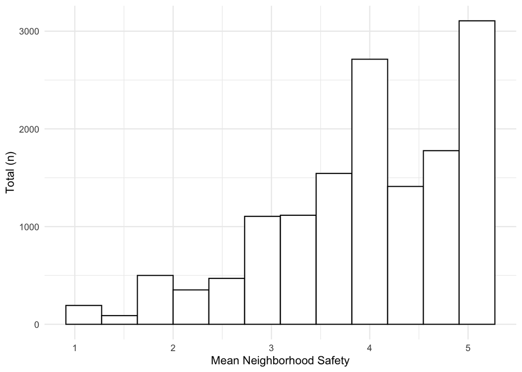

```r
abcd_incl %>%
  select(neighb_phenx_ss_mean_p) %>%
  ggplot(aes(x = neighb_phenx_ss_mean_p)) +
  geom_histogram(bins = 12, fill = "white", colour = "black") +
  xlab("Mean Neighborhood Safety") +
  ylab("Total (n)")+
  theme_minimal()
```

### 5.1.2 Parental income,

TOTAL COMBINED FAMILY INCOME for the past 12 months

```r
abcd_incl %>%
  filter(event_name=="Year 1") %>%
  select(income_yr1_f) %>%
  filter(!is.na(income_yr1_f)) %>%
  group_by(income_yr1_f) %>%
  summarise(Total = n()) %>%
  mutate('Proportion %' = Total/sum(Total)*100)
```

```
## # A tibble: 12 x 3
##    income_yr1_f              Total `Proportion %`
##    <fct>                     <int>          <dbl>
##  1 Less than $5,000            141           2.01
##  2 $5,000 through $11,999      164           2.33
##  3 $12,000 through $15,999     115           1.64
##  4 $16,000 through $24,999     241           3.43
##  5 $25,000 through $34,999     312           4.44
##  6 $35,000 through $49,999     479           6.81
##  7 $50,000 through $74,999     849          12.1
##  8 $75,000 through $99,999     954          13.6
##  9 $100,000 through $199,999  2382          33.9
## 10 $200,000 and greater        955          13.6
## 11 Refuse to answer            217           3.09
## 12 Don't Know                  221           3.14
```

```r
abcd_incl %>%
  filter(event_name=="Year 1") %>%
  select(income_base_f) %>%
  filter(!is.na(income_base_f)) %>%
  group_by(income_base_f) %>%
  summarise(Total = n()) %>%
  mutate('Proportion %' = Total/sum(Total)*100)
```

```
## # A tibble: 0 x 3
## # … with 3 variables: income_base_f <fct>, Total <int>, `Proportion %` <dbl>
```

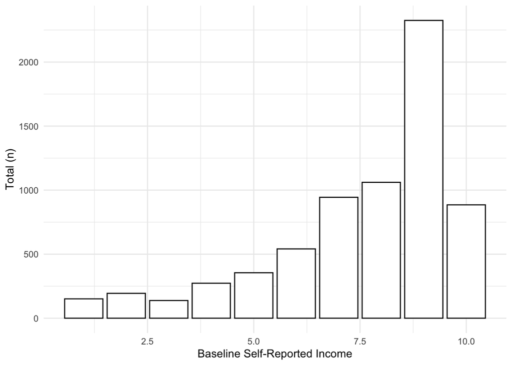

```r
abcd_incl %>%
  filter(event_name == "Baseline", demo_comb_income_v2 != 777, demo_comb_income_v2 != 999) %>%
  select(demo_comb_income_v2) %>%
  ggplot(aes(x = demo_comb_income_v2)) +
  geom_histogram(stat = "count", fill = "white", colour = "black") +
  xlab("Baseline Self-Reported Income") +
  ylab("Total (n)")+
  theme_minimal()
```

### 5.1.3 Area Deprivation Index (ADI)

Residential History Derived Scores; weighted sum score used to create the percentile rankings described in the pre-reg report (Kind & Buckingham, 2018; doi: 10.1056/NEJMp1802313). Percentile ranking is used to provide a visualization of the weighted sum score in the Neighborhood Altas map. clarify (to reviewers) using the weighted sum score provided in DEAP, not the percentile rankings (not available in DEAP) that are used to visualize the ADI weighted sum score.

The `Area Deprivation Index` is composed of 17 education, employment, housing-quality, and poverty measures original drawn from census data and updated with recent American Community Survey data. (Kind & Buckingham, 2018). Thus, includes similar limitations as ACS/Census data (limited account of undocumented-immigrant populations).

- cross reference of over 69 million nine-digit Zip Codes
- provides the distribution neighborhood disadvantage throughout us. See map at: (http://www.neighborhoodatlas.medicine.wisc.edu.proxy.lib.umich.edu/)

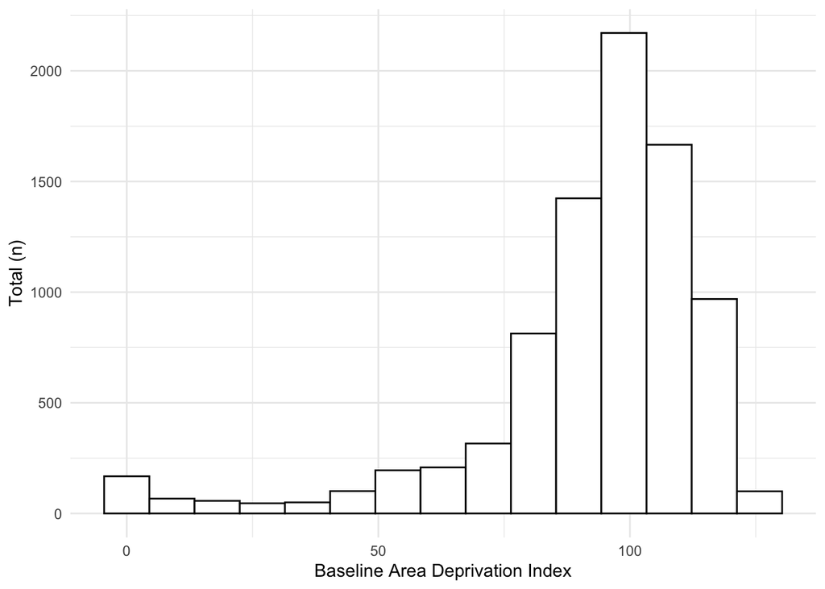

```r
abcd_incl %>%
  select(reshist_addr1_adi_wsum) %>%
  ggplot(aes(x = reshist_addr1_adi_wsum)) +
  geom_histogram(bins = 15, fill = "white", colour = "black") +
  xlab("Baseline Area Deprivation Index") +
  ylab("Total (n)")+
  theme_minimal()
```

```r
abcd_incl %>%
  select(reshist_addr1_adi_wsum) %>%
  summarise(Min_of_sample = min(reshist_addr1_adi_wsum, na.rm = T), Max_of_sample = max(reshist_addr1_adi_wsum, na.rm = T))
```

```
## # A tibble: 1 x 2
##   Min_of_sample Max_of_sample
##           <dbl>         <dbl>
## 1             0          126.
```

## 5.2 Moderator

### 5.2.1 Parental acceptance

CRPBI - Acceptance Subscale Mean of Report by Parent Completing Protocol by youth: (crpbi_parent1_y + crpbi_parent2_y + crpbi_parent3_y], crpbi_parent4_y + crpbi_parent5_y)/5; Validation: Minimum of 4 items answered; [1-not like him/her to 3-a lot like him/her];

- Q1 crpbi_acceptance_studycaregiver1 - Makes me feel better after talking over my worries with him/her;
- Q2 crpbi_acceptance_studycaregiver2 - Smiles at me very often;
- Q3 crpbi_acceptance_studycaregiver3 - Is able to make me feel better when I am upset.
- Q4 crpbi_acceptance_studycaregiver4 - Believes in showing his/her love for me.
- Q5 crpbi_acceptance_studycaregiver5 - Is easy to talk to.

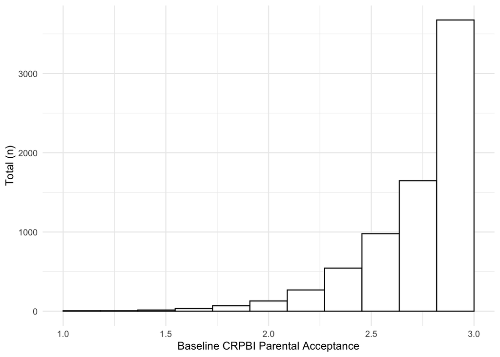

```r
abcd_incl %>%
  filter(event_name == "Baseline") %>%
  select(crpbi_acceptance_ss_studycaregiver) %>%
  ggplot(aes(x = crpbi_acceptance_ss_studycaregiver)) +
  geom_histogram(bins = 12, fill = "white", colour = "black") +
  xlab("Baseline CRPBI Parental Acceptance") +
  ylab("Total (n)")+
  theme_minimal()
```

## 5.3 Amyg Activation

### 5.3.1 Faces versus placed ROI mean beta

Left & Right Amygdala activation

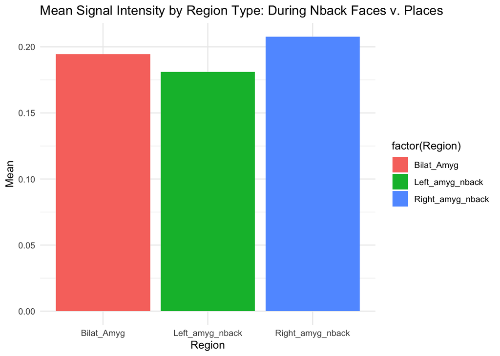

```r
#######
#   Rainclouds
######
library(cowplot)
library(dplyr)
library(readr)
library(devtools)
source("https://raw.githubusercontent.com/RainCloudPlots/RainCloudPlots/master/tutorial_R/R_rainclouds.R")

abcd_brain = abcd_incl %>% filter(event_name=='Baseline')




abcd_brain %>%
  select(Left_amyg_nback, Right_amyg_nback, Bilat_Amyg) %>%
  gather(key = "Region",
         value = "Beta",
         Left_amyg_nback:Bilat_Amyg) %>%
  group_by(Region) %>%
  summarise(Mean = mean(Beta)) %>%
  ggplot(aes(x = Region, y = Mean, fill =factor(Region))) +
  geom_bar(stat="identity", position = "dodge") +
  ggtitle("Mean Signal Intensity by Region Type: During Nback Faces v. Places") +
  theme_minimal()
```

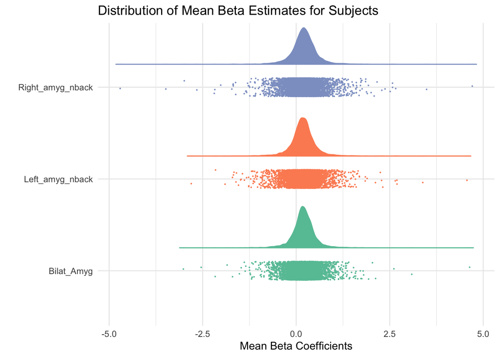

```r
abcd_brain %>%
  select(Left_amyg_nback, Right_amyg_nback, Bilat_Amyg) %>%
  gather(key = "Region",
         value = "Beta",
         Left_amyg_nback:Bilat_Amyg) %>%
  ggplot(aes(x=Region, y = Beta, fill = Region, colour = Region))+
  geom_flat_violin(position = position_nudge(x = .25, y = 0),adjust =1, trim = FALSE)+ # x - adjusts position of boxplot in relation to distribution. Y displaces distribution, adjust value  modifies distribution type (smoothing kernel)
  geom_point(position = position_jitter(width = .1), size = .1)+ # widtih changes height of points distribution, size changes point size
  #geom_boxplot(aes(x = as.numeric(event_name)+0.25, y = cbcl_scr_syn_internal_t),outlier.shape = NA, alpha = 0.3, width = .1, colour = "BLACK") + # .25 CHANGES POSITIONS OF BOXPLOT
  ylab('Mean Beta Coefficients') +
  xlab('') +
  coord_flip() + # flips axis
  theme_cowplot() +
  guides(fill = FALSE, colour = FALSE) +
  scale_colour_brewer(palette = "Set2") +
  scale_fill_brewer(palette = "Set2") +
  ggtitle("Distribution of Mean Beta Estimates for Subjects") +
  theme_minimal()
```

## 5.4 Outcome

### 5.4.1 INTERNALIZING SCORE

ABCD Parent Child Behavior Checklist Scores Aseba (CBCL)

```r
abcd_incl  %>%
  filter(event_name=='Baseline') %>%
  select(cbcl_scr_syn_internal_t) %>%
  summarise("Responders CBCL Baseline" = n(), Mean = mean(cbcl_scr_syn_internal_t, na.rm = T), SD = sd(cbcl_scr_syn_internal_t, na.rm = T))
```

```
## # A tibble: 1 x 3
##   `Responders CBCL Baseline`  Mean    SD
##                        <int> <dbl> <dbl>
## 1                       7385  48.2  10.4
```

```r
abcd_incl  %>%
  filter(event_name=='Year 1') %>%
  select(cbcl_scr_syn_internal_t) %>%
  summarise("Responders CBCL Year 1" = n(), Mean = mean(cbcl_scr_syn_internal_t, na.rm = T), SD = sd(cbcl_scr_syn_internal_t, na.rm = T))
```

```
## # A tibble: 1 x 3
##   `Responders CBCL Year 1`  Mean    SD
##                      <int> <dbl> <dbl>
## 1                     7049  48.4  10.4
```

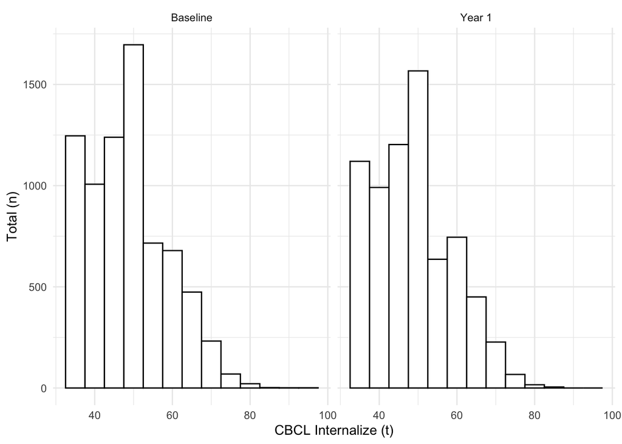

```r
abcd_incl  %>%
  select(cbcl_scr_syn_internal_t, event_name) %>%
  ggplot(aes (x= cbcl_scr_syn_internal_t)) +
  geom_histogram(binwidth = 5, fill = "white", colour = "black") +
  xlab("CBCL Internalize (t)") +
  ylab("Total (n)")+
  facet_wrap(~event_name)+
  theme_minimal()
```

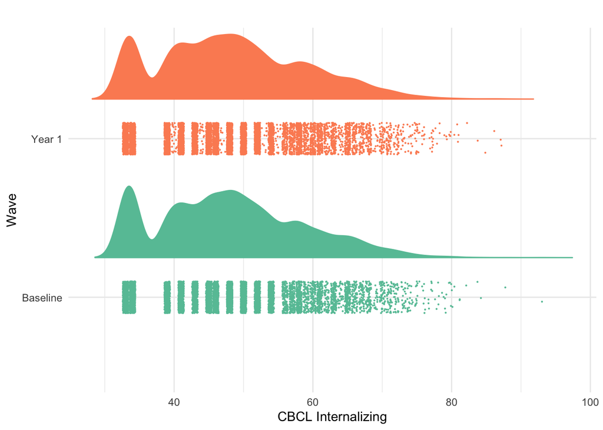

```r
### rain clouds
abcd_sample = abcd_incl %>% filter(event_name=='Baseline' | event_name=='Year 1')

abcd_sample %>%
  ggplot(aes(x=event_name, y = cbcl_scr_syn_internal_t, fill = event_name, colour = event_name))+
  geom_flat_violin(position = position_nudge(x = .25, y = 0),adjust =1, trim = FALSE)+ # x - adjusts position of boxplot in relation to distribution. Y displaces distribution, adjust value  modifies distribution type (smoothing kernel)
  geom_point(position = position_jitter(width = .1), size = .1)+ # widtih changes height of points distribution, size changes point size
  #geom_boxplot(aes(x = as.numeric(event_name)+0.25, y = cbcl_scr_syn_internal_t),outlier.shape = NA, alpha = 0.3, width = .1, colour = "BLACK") + # .25 CHANGES POSITIONS OF BOXPLOT
  ylab('CBCL Internalizing') +
  xlab('Wave') +
  coord_flip() + # flips axis
  theme_cowplot() +
  guides(fill = FALSE, colour = FALSE) +
  scale_colour_brewer(palette = "Set2") +
  scale_fill_brewer(palette = "Set2") +
  ggtitle("") +
  theme_minimal()
```

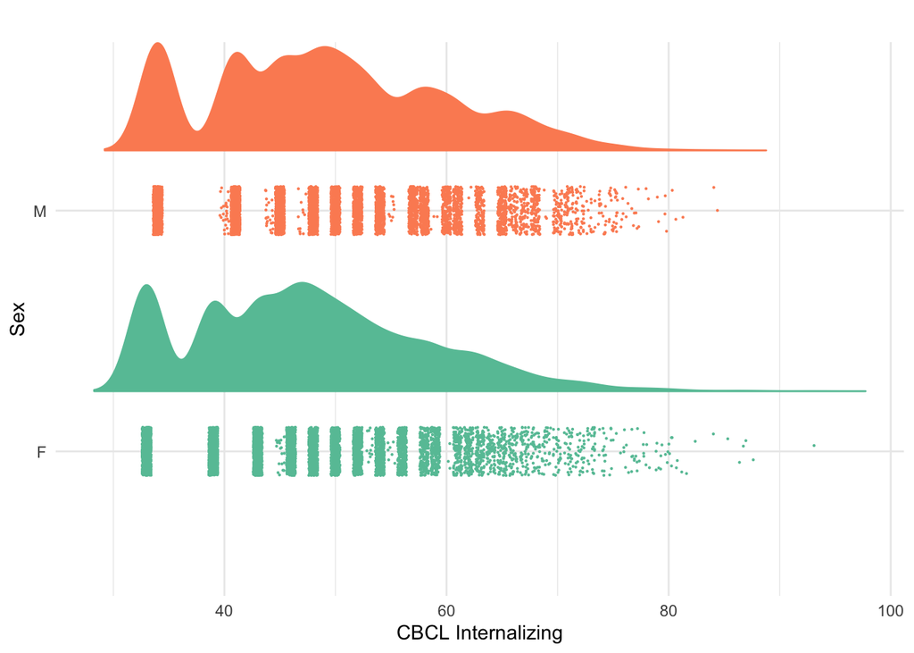

```r
abcd_sample %>%
  ggplot(aes(x=sex, y = cbcl_scr_syn_internal_t, fill = sex, colour = sex))+
  geom_flat_violin(position = position_nudge(x = .25, y = 0),adjust =1, trim = FALSE)+ # x - adjusts position of boxplot in relation to distribution. Y displaces distribution, adjust value  modifies distribution type (smoothing kernel)
  geom_point(position = position_jitter(width = .1), size = .1)+
  ylab('CBCL Internalizing') +
  xlab('Sex') +
  coord_flip() + # flips axis
  theme_cowplot() +
  guides(fill = FALSE, colour = FALSE) +
  scale_colour_brewer(palette = "Set2") +
  scale_fill_brewer(palette = "Set2") +
  ggtitle("") +
  theme_minimal()
```

## 5.5 Covariates

### 5.5.1 Puberty

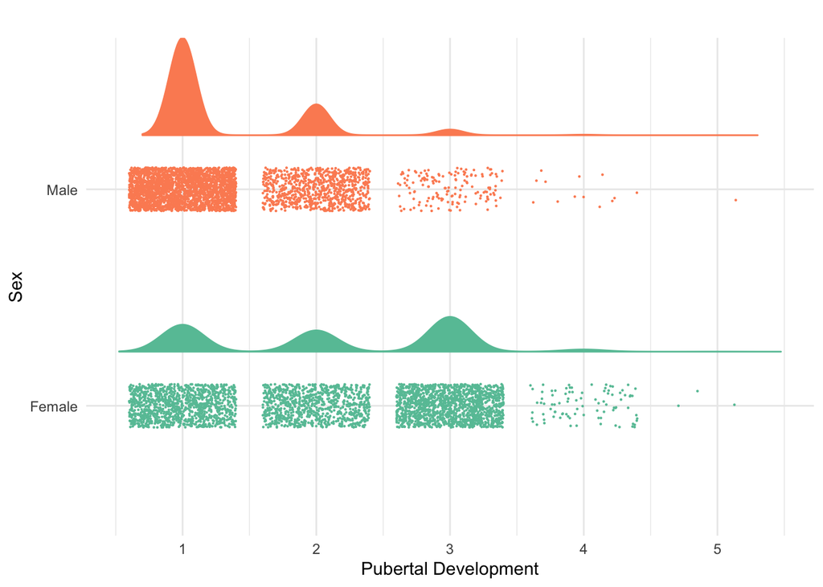

```r
abcd_sample %>%
  filter(!is.na(sex), event_name == "Baseline") %>%
  mutate(Sex_r = if_else(sex == "F", "Female", "Male")) %>%
  ggplot(aes(x=Sex_r, y = puberty, fill = Sex_r, colour = Sex_r))+
  geom_flat_violin(position = position_nudge(x = .25, y = 0),adjust =1, trim = FALSE)+ # x - adjusts position of boxplot in relation to distribution. Y displaces distribution, adjust value  modifies distribution type (smoothing kernel)
  geom_point(position = position_jitter(width = .1), size = .1)+ # widtih changes height of points distribution, size changes point size
  ylab('Pubertal Development') +
  xlab('Sex') +
  coord_flip() + # flips axis
  theme_cowplot() +
  guides(fill = FALSE, colour = FALSE) +
  scale_colour_brewer(palette = "Set2") +
  scale_fill_brewer(palette = "Set2") +
  ggtitle("") +
  theme_minimal()
```

```r
abcd_sample %>%
  filter(!is.na(sex), event_name == "Baseline") %>%
  mutate(Sex_r = if_else(sex == "F", "Female", "Male")) %>%
  group_by(Sex_r) %>%
  summarise(Mean = mean(puberty, na.rm = T), SD = sd(puberty, na.rm = T), Subjs = n())
```

```
## # A tibble: 2 x 4
##   Sex_r   Mean    SD Subjs
##   <chr>  <dbl> <dbl> <int>
## 1 Female  2.15 0.901  3656
## 2 Male    1.32 0.573  3729
```

### 5.5.2 Scanner Manufacturer

```r
abcd_incl %>%
  filter(event_name == "Baseline") %>%
  select(mri_info_manufacturer) %>%
  group_by(mri_info_manufacturer) %>%
  summarize(count = n())
```

```
## # A tibble: 4 x 2
##   mri_info_manufacturer   count
##   <chr>                   <int>
## 1 GE MEDICAL SYSTEMS       1698
## 2 Philips Medical Systems   917
## 3 SIEMENS                  4636
## 4 <NA>                      134
```

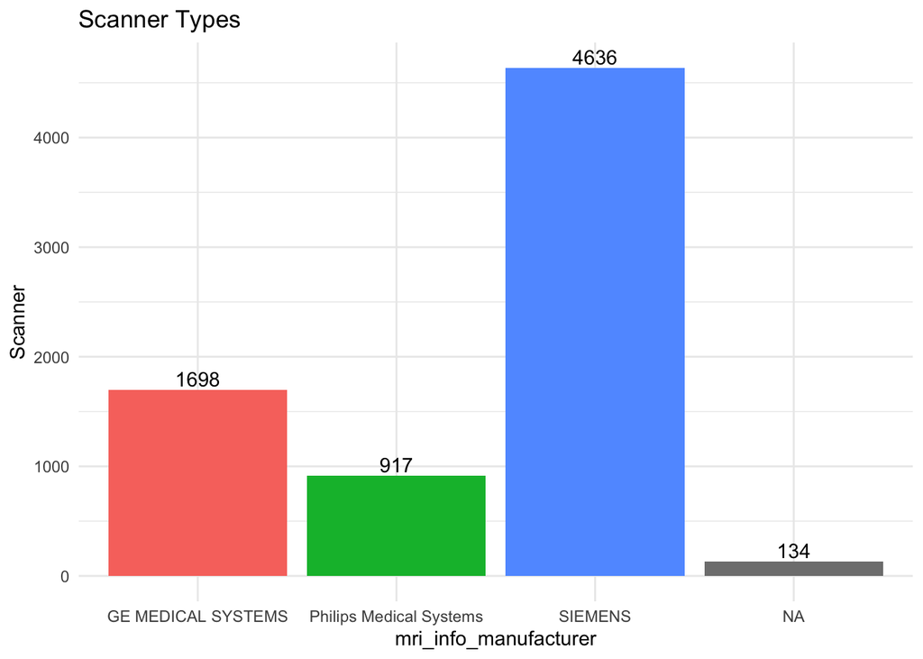

```r
abcd_incl %>%
  filter(event_name == "Baseline") %>%
  select(mri_info_manufacturer) %>%
  group_by(mri_info_manufacturer) %>%
  summarize(Scanner = n()) %>%
  ggplot(aes(x = mri_info_manufacturer, y = Scanner, fill =as.factor(mri_info_manufacturer))) +
  geom_bar(stat="identity", position = "dodge") +
  ggtitle("Scanner Types") +
  geom_text(aes(label=Scanner), position=position_dodge(width=0.9), vjust=-0.25)+
  scale_fill_discrete(name="Scanner Type",
                      breaks=c(1:3),
                      labels=c(1:3))+
  theme(axis.text.x=element_text(size=11, angle=30, vjust=.8, hjust=0.8))+
  theme_minimal()
```

### 5.5.3 ABCD Site

```r
abcd_incl %>%
  filter(event_name == "Baseline") %>%
  select(abcd_site) %>%
  group_by(abcd_site) %>%
  summarize(count = n()) %>%
  arrange(count)
```

```
## # A tibble: 22 x 2
##    abcd_site count
##    <chr>     <int>
##  1 site22       20
##  2 site15      185
##  3 site08      187
##  4 site07      211
##  5 site05      224
##  6 site18      233
##  7 site01      257
##  8 site09      260
##  9 site11      283
## 10 site19      294
## # … with 12 more rows
```

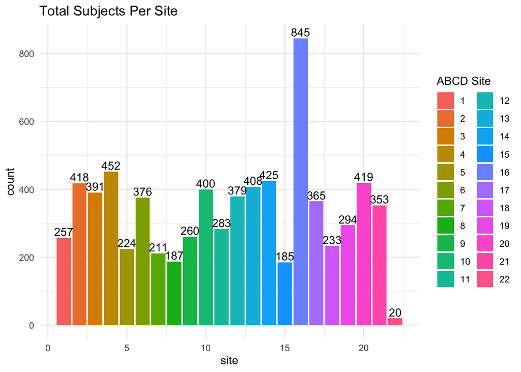

```r
abcd_incl %>%
  filter(event_name == "Baseline") %>%
  select(site) %>%
  group_by(site) %>%
  summarize(count = n()) %>%
  ggplot(aes(x = site, y = count, fill =as.factor(site))) +
  geom_bar(stat="identity", position = "dodge") +
  ggtitle("Total Subjects Per Site") +
  geom_text(aes(label=count), position=position_dodge(width=0.9), vjust=-0.25)+
  scale_fill_discrete(name="ABCD Site",
                      breaks=c(1:22),
                      labels=c(1:22))+
  theme(axis.text.x=element_text(size=11, angle=30, vjust=.8, hjust=0.8))+
  theme_minimal()
```

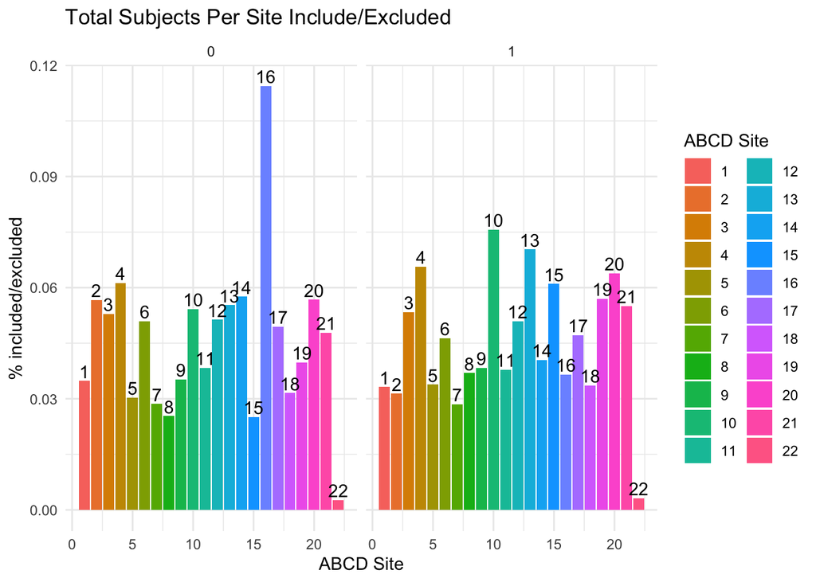

```r
abcd %>%
  filter(event_name == "Baseline") %>%
  select(site,  exclude) %>%
  group_by(exclude, site) %>%
  summarize(count = n()) %>%
  summarize(count_prop = count/sum(count), count, site) %>%
  ggplot(aes(x = site, y = count_prop, fill =as.factor(site))) +
  geom_bar(stat="identity", position = "dodge") +
  xlab("ABCD Site") +
  ylab("% included/excluded") +
  ggtitle("Total Subjects Per Site Include/Excluded") +
  facet_wrap(~exclude) +
  geom_text(aes(label=site), position=position_dodge(width=0.9), vjust=-0.25)+
  scale_fill_discrete(name="ABCD Site",
                      breaks=c(1:22),
                      labels=c(1:22))+
  theme(axis.text.x=element_text(size=11, angle=30, vjust=.8, hjust=0.8))+
  theme_minimal()
```

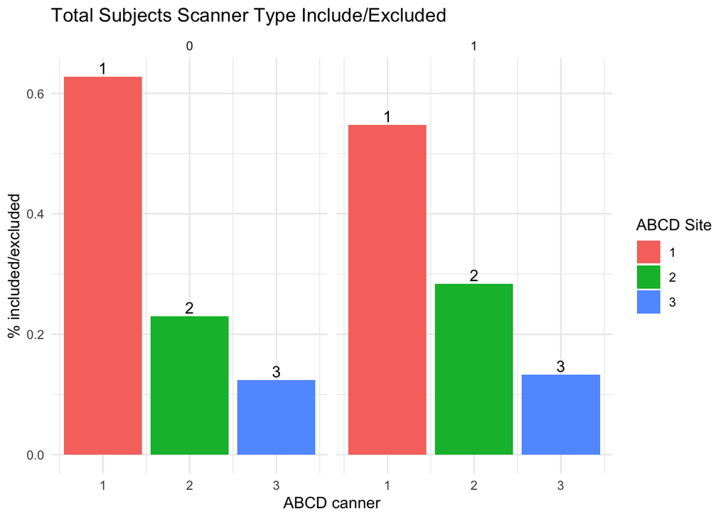

```r
abcd %>%
  filter(event_name == "Baseline") %>%
  select(scanner_type,  exclude) %>%
  group_by(exclude, scanner_type) %>%
  summarize(count = n()) %>%
  summarize(count_prop = count/sum(count), count, scanner_type) %>%
  ggplot(aes(x = scanner_type, y = count_prop, fill =as.factor(scanner_type))) +
  geom_bar(stat="identity", position = "dodge") +
  xlab("ABCD canner") +
  ylab("% included/excluded") +
  ggtitle("Total Subjects Scanner Type Include/Excluded") +
  facet_wrap(~exclude) +
  geom_text(aes(label=scanner_type), position=position_dodge(width=0.9), vjust=-0.25)+
  scale_fill_discrete(name="ABCD Site",
                      breaks=c(1:22),
                      labels=c(1:22))+
  theme(axis.text.x=element_text(size=11, angle=30, vjust=.8, hjust=0.8))+
  theme_minimal()
```

### 5.5.4 Age (months) at baseline

### 5.5.5 Sex

```r
abcd_incl %>%
  filter(event_name == "Baseline") %>%
  select(sex, subj_id) %>% #subject ID;s
   group_by(sex) %>% # sex at birth
  distinct(subj_id) %>%
  summarise(count = n())
```

```
## # A tibble: 2 x 2
##   sex   count
##   <chr> <int>
## 1 F      3656
## 2 M      3729
```

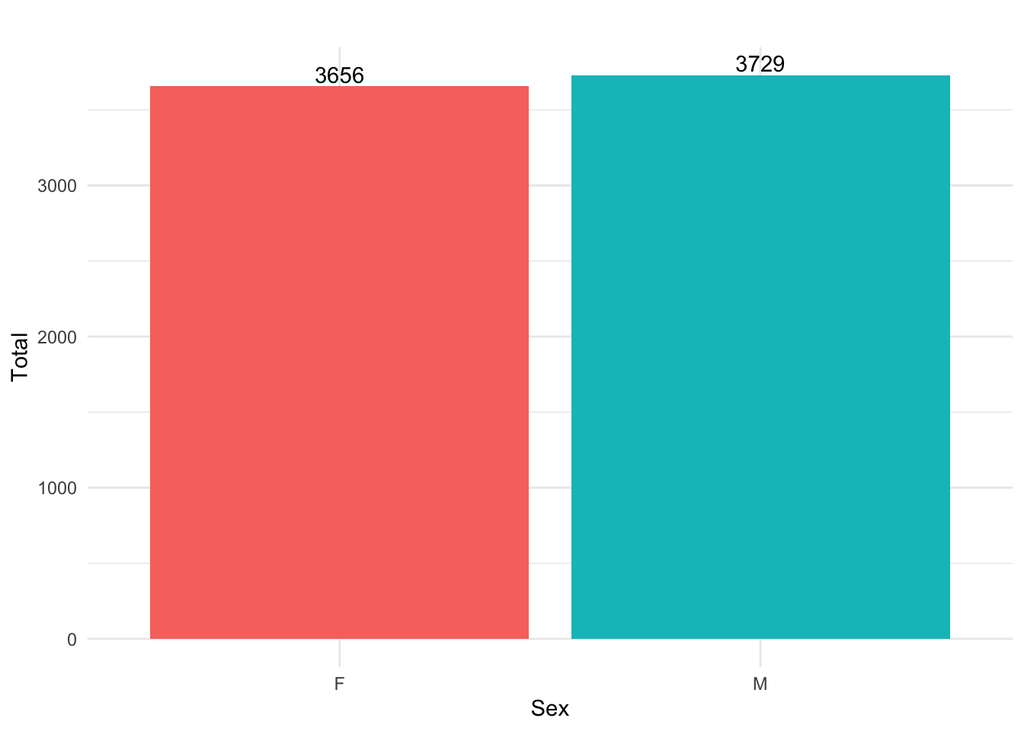

```r
abcd_incl %>%
  filter(event_name == "Baseline") %>%
  select(sex) %>%
  group_by(sex) %>%
  summarize(sex_t = n()) %>%
  ggplot(aes(x = sex, y = sex_t, fill =as.factor(sex_t))) +
  geom_bar(stat="identity", position = "dodge") +
  ggtitle("") +
  ylab("Total") +
  xlab("Sex") +
  geom_text(aes(label=sex_t), position=position_dodge(width=0.9), vjust=-0.25)+
  scale_fill_discrete(name="Sex",
                      breaks=c(1:3),
                      labels=c(1:3))+
  theme(axis.text.x=element_text(size=11, angle=30, vjust=.8, hjust=0.8))+
  theme_minimal()
```

### 5.5.6 Race

```r
# 1: White | 2: Black | 3: Asian | 4: Other/Mixed
abcd_incl %>%
  filter(event_name == "Baseline") %>%
  select(race5) %>%
         group_by(race5) %>% #
           summarise(count = n())
```

```
## # A tibble: 6 x 2
##   race5    count
##   <fct>    <int>
## 1 White     4259
## 2 Black      786
## 3 Hispanic  1414
## 4 Asian      165
## 5 Other      760
## 6 <NA>         1
```

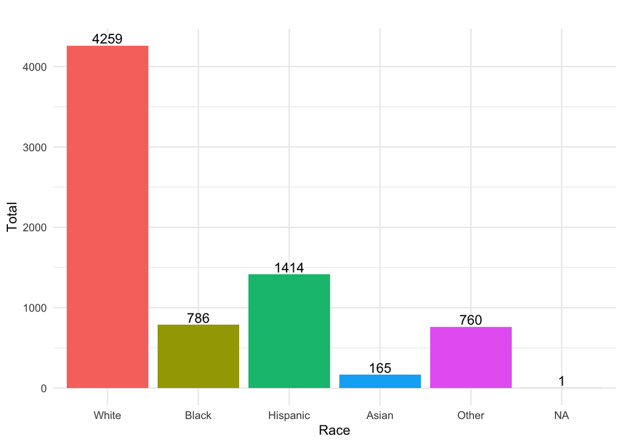

```r
abcd_incl %>%
  filter(event_name == "Baseline") %>%
  select(race5) %>%
  group_by(race5) %>%
  summarize(race = n()) %>%
  ggplot(aes(x = race5, y = race, fill =as.factor(race5))) +
  geom_bar(stat="identity", position = "dodge") +
  ggtitle("") +
  ylab("Total") +
  xlab("Race") +
  geom_text(aes(label=race), position=position_dodge(width=0.9), vjust=-0.25)+
  scale_fill_discrete(name="Race",
                      breaks=c(1:3),
                      labels=c(1:3))+
  theme(axis.text.x=element_text(size=11, angle=30, vjust=.8, hjust=0.8))+
  theme_minimal()
```

### 5.5.7 Family relation

rel_family_id: These values are derived from information contained in pairs of participant IDs that are marked as either sibling, twin, or triplet. The family ID is the same for all participants in a family and different between families. Inside a family each set of twins, triplets or siblings will have a unique group ID. A family with 2 sets of twins and one siblings will there have three unique group IDs.

# 6 Tables

## 6.1 Descriptives: Included/Excluded

```r
# table creating using http://thatdatatho.com/2018/08/20/easily-create-descriptive-summary-statistic-tables-r-studio/
library(table1)
library(MatchIt)
table1::label(abcd$interview_age) <- "Age (Months)"
table1::label(abcd$sex) <- "Sex"
table1::label(abcd$income_base_f) <- "Family Income"
table1::label(abcd$race5) <- "Race"
table1::label(abcd$puberty) <- "Puberty"
table1::label(abcd$cbcl_scr_syn_internal_t) <- "Internalizing"
table1::label(abcd$neighb_phenx_ss_mean_p) <- "Neighborhood Safety Mean"
table1::label(abcd$reshist_addr1_adi_wsum) <- "ADI"
table1::label(abcd$crpbi_acceptance_ss_studycaregiver) <- "Parental Acceptance"


table1::table1(~interview_age + sex + income_base_f + race5 + puberty + cbcl_scr_syn_internal_t + neighb_phenx_ss_mean_p + reshist_addr1_adi_wsum + crpbi_acceptance_ss_studycaregiver | as.factor(exclude)*event_name, data = abcd)
```

|  | 0 Baseline (N=7385) | 0 Year 1 (N=11235) | 1 Baseline (N=4493) | Overall Baseline (N=11878) | Overall Year 1 (N=11235) |
| --- | --- | --- | --- | --- | --- |
| Age (Months) |  |  |  |  |  |
| Mean (SD) | 120 (7.52) | 131 (7.73) | 118 (7.33) | 119 (7.50) | 131 (7.73) |
| Median [Min, Max] | 120 [107, 132] | 131 [109, 156] | 117 [107, 133] | 119 [107, 133] | 131 [109, 156] |
| Sex |  |  |  |  |  |
| F | 3656 (49.5%) | 5356 (47.7%) | 2026 (45.1%) | 5682 (47.8%) | 5356 (47.7%) |
| M | 3729 (50.5%) | 5879 (52.3%) | 2467 (54.9%) | 6196 (52.2%) | 5879 (52.3%) |
| Family Income |  |  |  |  |  |
| Less than $5,000 | 151 (2.0%) | 0 (0%) | 266 (5.9%) | 417 (3.5%) | 0 (0%) |
| $5,000 through $11,999 | 194 (2.6%) | 0 (0%) | 227 (5.1%) | 421 (3.5%) | 0 (0%) |
| $12,000 through $15,999 | 138 (1.9%) | 0 (0%) | 136 (3.0%) | 274 (2.3%) | 0 (0%) |
| $16,000 through $24,999 | 273 (3.7%) | 0 (0%) | 251 (5.6%) | 524 (4.4%) | 0 (0%) |
| $25,000 through $34,999 | 355 (4.8%) | 0 (0%) | 299 (6.7%) | 654 (5.5%) | 0 (0%) |
| $35,000 through $49,999 | 541 (7.3%) | 0 (0%) | 393 (8.7%) | 934 (7.9%) | 0 (0%) |
| $50,000 through $74,999 | 944 (12.8%) | 0 (0%) | 555 (12.4%) | 1499 (12.6%) | 0 (0%) |
| $75,000 through $99,999 | 1061 (14.4%) | 0 (0%) | 511 (11.4%) | 1572 (13.2%) | 0 (0%) |
| $100,000 through $199,999 | 2325 (31.5%) | 0 (0%) | 990 (22.0%) | 3315 (27.9%) | 0 (0%) |
| $200,000 and greater | 885 (12.0%) | 0 (0%) | 365 (8.1%) | 1250 (10.5%) | 0 (0%) |
| Refuse to answer | 278 (3.8%) | 0 (0%) | 234 (5.2%) | 512 (4.3%) | 0 (0%) |
| Don't Know | 240 (3.2%) | 0 (0%) | 264 (5.9%) | 504 (4.2%) | 0 (0%) |
| Missing | 0 (0%) | 11235 (100%) | 2 (0.0%) | 2 (0.0%) | 11235 (100%) |
| Race |  |  |  |  |  |
| White | 4259 (57.7%) | 5986 (53.3%) | 1923 (42.8%) | 6182 (52.0%) | 5986 (53.3%) |
| Black | 786 (10.6%) | 1597 (14.2%) | 998 (22.2%) | 1784 (15.0%) | 1597 (14.2%) |
| Hispanic | 1414 (19.1%) | 2226 (19.8%) | 997 (22.2%) | 2411 (20.3%) | 2226 (19.8%) |
| Asian | 165 (2.2%) | 243 (2.2%) | 87 (1.9%) | 252 (2.1%) | 243 (2.2%) |
| Other | 760 (10.3%) | 1176 (10.5%) | 487 (10.8%) | 1247 (10.5%) | 1176 (10.5%) |
| Missing | 1 (0.0%) | 7 (0.1%) | 1 (0.0%) | 2 (0.0%) | 7 (0.1%) |
| Puberty |  |  |  |  |  |
| Mean (SD) | 1.73 (0.858) | 2.08 (0.986) | 1.79 (0.884) | 1.76 (0.868) | 2.08 (0.986) |
| Median [Min, Max] | 1.00 [1.00, 5.00] | 2.00 [1.00, 5.00] | 2.00 [1.00, 5.00] | 1.00 [1.00, 5.00] | 2.00 [1.00, 5.00] |
| Missing | 237 (3.2%) | 562 (5.0%) | 235 (5.2%) | 472 (4.0%) | 562 (5.0%) |
| Internalizing |  |  |  |  |  |
| Mean (SD) | 48.2 (10.4) | 48.6 (10.6) | 48.9 (11.0) | 48.4 (10.6) | 48.6 (10.6) |
| Median [Min, Max] | 48.0 [33.0, 93.0] | 48.0 [33.0, 87.0] | 48.0 [33.0, 88.0] | 48.0 [33.0, 93.0] | 48.0 [33.0, 87.0] |
| Missing | 2 (0.0%) | 44 (0.4%) | 6 (0.1%) | 8 (0.1%) | 44 (0.4%) |
| Neighborhood Safety Mean |  |  |  |  |  |
| Mean (SD) | 3.96 (0.929) | 3.89 (0.952) | 3.77 (1.04) | 3.89 (0.976) | 3.89 (0.952) |
| Median [Min, Max] | 4.00 [1.00, 5.00] | 4.00 [1.00, 5.00] | 4.00 [1.00, 5.00] | 4.00 [1.00, 5.00] | 4.00 [1.00, 5.00] |
| Missing | 26 (0.4%) | 54 (0.5%) | 21 (0.5%) | 47 (0.4%) | 54 (0.5%) |
| ADI |  |  |  |  |  |
| Mean (SD) | 91.4 (24.4) | 96.6 (19.2) | 94.9 (25.4) | 92.7 (24.8) | 96.6 (19.2) |
| Median [Min, Max] | 97.1 [0, 126] | 99.8 [1.10, 126] | 101 [0, 126] | 98.5 [0, 126] | 99.8 [1.10, 126] |
| Missing | 421 (5.7%) | 8943 (79.6%) | 276 (6.1%) | 697 (5.9%) | 8943 (79.6%) |
| Parental Acceptance |  |  |  |  |  |
| Mean (SD) | 2.79 (0.293) | 2.81 (0.288) | 2.77 (0.322) | 2.78 (0.304) | 2.81 (0.288) |
| Median [Min, Max] | 2.80 [1.00, 3.00] | 3.00 [1.00, 3.00] | 3.00 [1.00, 3.00] | 3.00 [1.00, 3.00] | 3.00 [1.00, 3.00] |
| Missing | 13 (0.2%) | 46 (0.4%) | 21 (0.5%) | 34 (0.3%) | 46 (0.4%) |

```r
#Creating included/excluded subset data for decriptives

library(table1)
library(MatchIt)
table1::label(abcd_incl$interview_age) <- "Age (Months)"
table1::label(abcd_incl$sex) <- "Sex"
table1::label(abcd_incl$income_base_f) <- "Family Income"
table1::label(abcd_incl$race5) <- "Race"
table1::label(abcd_incl$puberty) <- "Puberty"
table1::label(abcd_incl$cbcl_scr_syn_internal_t) <- "Internalizing"
table1::label(abcd_incl$neighb_phenx_ss_mean_p) <- "Neighborhood Safety Mean"
table1::label(abcd$reshist_addr1_adi_wsum) <- "ADI"
table1::label(abcd_incl$crpbi_acceptance_ss_studycaregiver) <- "Parental Acceptance"


table1::table1(~interview_age + sex + income_base_f + race5 + puberty + cbcl_scr_syn_internal_t + neighb_phenx_ss_mean_p + reshist_addr1_adi_wsum + crpbi_acceptance_ss_studycaregiver | as.factor(exclude)*event_name, data = abcd_incl)
```

|  | 0 Baseline (N=7385) | 0 Year 1 (N=7049) | Overall Baseline (N=7385) | Overall Year 1 (N=7049) |
| --- | --- | --- | --- | --- |
| Age (Months) |  |  |  |  |
| Mean (SD) | 120 (7.52) | 132 (7.76) | 120 (7.52) | 132 (7.76) |
| Median [Min, Max] | 120 [107, 132] | 132 [109, 156] | 120 [107, 132] | 132 [109, 156] |
| Sex |  |  |  |  |
| F | 3656 (49.5%) | 3474 (49.3%) | 3656 (49.5%) | 3474 (49.3%) |
| M | 3729 (50.5%) | 3575 (50.7%) | 3729 (50.5%) | 3575 (50.7%) |
| Family Income |  |  |  |  |
| Less than $5,000 | 151 (2.0%) | 0 (0%) | 151 (2.0%) | 0 (0%) |
| $5,000 through $11,999 | 194 (2.6%) | 0 (0%) | 194 (2.6%) | 0 (0%) |
| $12,000 through $15,999 | 138 (1.9%) | 0 (0%) | 138 (1.9%) | 0 (0%) |
| $16,000 through $24,999 | 273 (3.7%) | 0 (0%) | 273 (3.7%) | 0 (0%) |
| $25,000 through $34,999 | 355 (4.8%) | 0 (0%) | 355 (4.8%) | 0 (0%) |
| $35,000 through $49,999 | 541 (7.3%) | 0 (0%) | 541 (7.3%) | 0 (0%) |
| $50,000 through $74,999 | 944 (12.8%) | 0 (0%) | 944 (12.8%) | 0 (0%) |
| $75,000 through $99,999 | 1061 (14.4%) | 0 (0%) | 1061 (14.4%) | 0 (0%) |
| $100,000 through $199,999 | 2325 (31.5%) | 0 (0%) | 2325 (31.5%) | 0 (0%) |
| $200,000 and greater | 885 (12.0%) | 0 (0%) | 885 (12.0%) | 0 (0%) |
| Refuse to answer | 278 (3.8%) | 0 (0%) | 278 (3.8%) | 0 (0%) |
| Don't Know | 240 (3.2%) | 0 (0%) | 240 (3.2%) | 0 (0%) |
| Missing | 0 (0%) | 7049 (100%) | 0 (0%) | 7049 (100%) |
| Race |  |  |  |  |
| White | 4259 (57.7%) | 4139 (58.7%) | 4259 (57.7%) | 4139 (58.7%) |
| Black | 786 (10.6%) | 707 (10.0%) | 786 (10.6%) | 707 (10.0%) |
| Hispanic | 1414 (19.1%) | 1319 (18.7%) | 1414 (19.1%) | 1319 (18.7%) |
| Asian | 165 (2.2%) | 160 (2.3%) | 165 (2.2%) | 160 (2.3%) |
| Other | 760 (10.3%) | 720 (10.2%) | 760 (10.3%) | 720 (10.2%) |
| Missing | 1 (0.0%) | 4 (0.1%) | 1 (0.0%) | 4 (0.1%) |
| Puberty |  |  |  |  |
| Mean (SD) | 1.73 (0.858) | 2.08 (0.990) | 1.73 (0.858) | 2.08 (0.990) |
| Median [Min, Max] | 1.00 [1.00, 5.00] | 2.00 [1.00, 5.00] | 1.00 [1.00, 5.00] | 2.00 [1.00, 5.00] |
| Missing | 237 (3.2%) | 329 (4.7%) | 237 (3.2%) | 329 (4.7%) |
| Internalizing |  |  |  |  |
| Mean (SD) | 48.2 (10.4) | 48.4 (10.4) | 48.2 (10.4) | 48.4 (10.4) |
| Median [Min, Max] | 48.0 [33.0, 93.0] | 48.0 [33.0, 87.0] | 48.0 [33.0, 93.0] | 48.0 [33.0, 87.0] |
| Missing | 2 (0.0%) | 22 (0.3%) | 2 (0.0%) | 22 (0.3%) |
| Neighborhood Safety Mean |  |  |  |  |
| Mean (SD) | 3.96 (0.929) | 3.95 (0.912) | 3.96 (0.929) | 3.95 (0.912) |
| Median [Min, Max] | 4.00 [1.00, 5.00] | 4.00 [1.00, 5.00] | 4.00 [1.00, 5.00] | 4.00 [1.00, 5.00] |
| Missing | 26 (0.4%) | 32 (0.5%) | 26 (0.4%) | 32 (0.5%) |
| reshist_addr1_adi_wsum |  |  |  |  |
| Mean (SD) | 91.4 (24.4) | 95.0 (19.0) | 91.4 (24.4) | 95.0 (19.0) |
| Median [Min, Max] | 97.1 [0, 126] | 97.7 [1.10, 124] | 97.1 [0, 126] | 97.7 [1.10, 124] |
| Missing | 421 (5.7%) | 5662 (80.3%) | 421 (5.7%) | 5662 (80.3%) |
| Parental Acceptance |  |  |  |  |
| Mean (SD) | 2.79 (0.293) | 2.82 (0.275) | 2.79 (0.293) | 2.82 (0.275) |
| Median [Min, Max] | 2.80 [1.00, 3.00] | 3.00 [1.00, 3.00] | 2.80 [1.00, 3.00] | 3.00 [1.00, 3.00] |
| Missing | 13 (0.2%) | 21 (0.3%) | 13 (0.2%) | 21 (0.3%) |

### Missing data analyses p-value/effect size

```r
# Effect size function, cohens D
cohens_d <- function(mean_1, mean_2, sd_1, sd_2){
  pooled_sd<- sqrt((sd_1^2+sd_2^2)/2)
  d <- (mean_1 - mean_2)/pooled_sd
  print(paste("cohens d = ",d))
  }
```

### 6.1.1 overall sample differences

```r
# Overall sample
# age
t.test(abcd$interview_age[abcd$event_name=="Baseline"] ~ abcd$exclude[abcd$event_name=="Baseline"])
```

```
##
##  Welch Two Sample t-test
##
## data:  abcd$interview_age[abcd$event_name == "Baseline"] by abcd$exclude[abcd$event_name == "Baseline"]
## t = 12.474, df = 9672.7, p-value < 2.2e-16
## alternative hypothesis: true difference in means is not equal to 0
## 95 percent confidence interval:
##  1.472513 2.021568
## sample estimates:
## mean in group 0 mean in group 1
##        119.6395        117.8925
```

```r
age <- abcd %>%
  filter(event_name=="Baseline") %>%
  group_by(exclude) %>%
  summarise(M_age = mean(interview_age, na.rm = T), SD_age = sd(interview_age, na.rm = T))

cohens_d(age$M_[1], age$M[2],
         age$SD[1],age$SD[2])
```

```
## [1] "cohens d =  "
```

```r
# baseline income
t.test(abcd$income_base_r[abcd$event_name=="Baseline"] ~ abcd$exclude[abcd$event_name=="Baseline"])
```

```
##
##  Welch Two Sample t-test
##
## data:  abcd$income_base_r[abcd$event_name == "Baseline"] by abcd$exclude[abcd$event_name == "Baseline"]
## t = 18.479, df = 7100.3, p-value < 2.2e-16
## alternative hypothesis: true difference in means is not equal to 0
## 95 percent confidence interval:
##  0.8243297 1.0199736
## sample estimates:
## mean in group 0 mean in group 1
##        7.563274        6.641122
```

```r
income <- abcd %>%
  filter(event_name=="Baseline") %>%
  group_by(exclude) %>%
  summarise(M = mean(income_base_r, na.rm = T), SD = sd(income_base_r, na.rm = T))

cohens_d(income$M[1], income$M[2],
         income$SD[1],income$SD[2])
```

```
## [1] "cohens d =  0.377121220986583"
```

```r
# Race
library(descr)
CrossTable(abcd$race5[abcd$event_name=="Baseline"], abcd$exclude[abcd$event_name=="Baseline"], chisq = TRUE)
```

```
##    Cell Contents
## |-------------------------|
## |                       N |
## | Chi-square contribution |
## |           N / Row Total |
## |           N / Col Total |
## |         N / Table Total |
## |-------------------------|
##
## =====================================================================
##                                              abcd$exclude[abcd$event_name == "Baseline"]
## abcd$race5[abcd$event_name == "Baseline"]         0         1   Total
## ---------------------------------------------------------------------
## White                                          4259      1923    6182
##                                              44.870    73.758
##                                               0.689     0.311   0.521
##                                               0.577     0.428
##                                               0.359     0.162
## ---------------------------------------------------------------------
## Black                                           786       998    1784
##                                              94.183   154.818
##                                               0.441     0.559   0.150
##                                               0.106     0.222
##                                               0.066     0.084
## ---------------------------------------------------------------------
## Hispanic                                       1414       997    2411
##                                               4.826     7.934
##                                               0.586     0.414   0.203
##                                               0.191     0.222
##                                               0.119     0.084
## ---------------------------------------------------------------------
## Asian                                           165        87     252
##                                               0.441     0.726
##                                               0.655     0.345   0.021
##                                               0.022     0.019
##                                               0.014     0.007
## ---------------------------------------------------------------------
## Other                                           760       487    1247
##                                               0.303     0.498
##                                               0.609     0.391   0.105
##                                               0.103     0.108
##                                               0.064     0.041
## ---------------------------------------------------------------------
## Total                                          7384      4492   11876
##                                               0.622     0.378
## =====================================================================
##
## Statistics for All Table Factors
##
## Pearson's Chi-squared test
## ------------------------------------------------------------
## Chi^2 = 382.3573      d.f. = 4      p <2e-16
```

```r
  #chi-square effect sizes Ф = sqrt(chi-square/coun in all cells) ==
sqrt(22.15/11881)
```

```
## [1] 0.04317779
```

```r
# gender
CrossTable(abcd$sex[abcd$event_name=="Baseline"], abcd$exclude[abcd$event_name=="Baseline"], chisq = TRUE)
```

```
##    Cell Contents
## |-------------------------|
## |                       N |
## | Chi-square contribution |
## |           N / Row Total |
## |           N / Col Total |
## |         N / Table Total |
## |-------------------------|
##
## ================================================================
##                                            abcd$exclude[abcd$event_name == "Baseline"]
## abcd$sex[abcd$event_name == "Baseline"]        0       1   Total
## ----------------------------------------------------------------
## F                                           3656    2026    5682
##                                            4.303   7.072
##                                            0.643   0.357   0.478
##                                            0.495   0.451
##                                            0.308   0.171
## ----------------------------------------------------------------
## M                                           3729    2467    6196
##                                            3.946   6.485
##                                            0.602   0.398   0.522
##                                            0.505   0.549
##                                            0.314   0.208
## ----------------------------------------------------------------
## Total                                       7385    4493   11878
##                                            0.622   0.378
## ================================================================
##
## Statistics for All Table Factors
##
## Pearson's Chi-squared test
## ------------------------------------------------------------
## Chi^2 = 21.8053      d.f. = 1      p = 3.02e-06
##
## Pearson's Chi-squared test with Yates' continuity correction
## ------------------------------------------------------------
## Chi^2 = 21.62879      d.f. = 1      p = 3.31e-06
```

```r
  #chi-square effect sizes Ф = sqrt(chi-square/coun in all cells) ==
sqrt(380.4872/11881)
```

```
## [1] 0.1789549
```

```r
# baseline puberty
t.test(abcd$puberty[abcd$event_name=="Baseline"] ~ abcd$exclude[abcd$event_name=="Baseline"])
```

```
##
##  Welch Two Sample t-test
##
## data:  abcd$puberty[abcd$event_name == "Baseline"] by abcd$exclude[abcd$event_name == "Baseline"]
## t = -3.7338, df = 8738.3, p-value = 0.0001898
## alternative hypothesis: true difference in means is not equal to 0
## 95 percent confidence interval:
##  -0.09638906 -0.03002298
## sample estimates:
## mean in group 0 mean in group 1
##        1.731533        1.794739
```

```r
puberty <- abcd %>%
  filter(event_name=="Baseline") %>%
  group_by(exclude) %>%
  summarise(M = mean(puberty, na.rm = T), SD = sd(puberty, na.rm = T))

cohens_d(puberty$M[1], puberty$M[2],
         puberty$SD[1],puberty$SD[2])
```

```
## [1] "cohens d =  -0.072551230459267"
```

```r
# baseline internalizing
t.test(abcd$cbcl_scr_syn_internal_t[abcd$event_name=="Baseline"] ~ abcd$exclude[abcd$event_name=="Baseline"])
```

```
##
##  Welch Two Sample t-test
##
## data:  abcd$cbcl_scr_syn_internal_t[abcd$event_name == "Baseline"] by abcd$exclude[abcd$event_name == "Baseline"]
## t = -3.4319, df = 9094.3, p-value = 0.000602
## alternative hypothesis: true difference in means is not equal to 0
## 95 percent confidence interval:
##  -1.0988975 -0.2999279
## sample estimates:
## mean in group 0 mean in group 1
##        48.18069        48.88010
```

```r
cbcl <- abcd %>%
  filter(event_name=="Baseline") %>%
  group_by(exclude) %>%
  summarise(M = mean(cbcl_scr_syn_internal_t, na.rm = T), SD = sd(cbcl_scr_syn_internal_t, na.rm = T))


cohens_d(cbcl$M[1], cbcl$M[2],
         cbcl$SD[1],cbcl$SD[2])
```

```
## [1] "cohens d =  -0.0653682291699216"
```

```r
# baseline Neighb SAFE
t.test(abcd$neighb_phenx_ss_mean_p[abcd$event_name=="Baseline"] ~ abcd$exclude[abcd$event_name=="Baseline"])
```

```
##
##  Welch Two Sample t-test
##
## data:  abcd$neighb_phenx_ss_mean_p[abcd$event_name == "Baseline"] by abcd$exclude[abcd$event_name == "Baseline"]
## t = 9.6974, df = 8632.6, p-value < 2.2e-16
## alternative hypothesis: true difference in means is not equal to 0
## 95 percent confidence interval:
##  0.1464615 0.2206743
## sample estimates:
## mean in group 0 mean in group 1
##        3.958464        3.774896
```

```r
Neigh_safe <- abcd %>%
  filter(event_name=="Baseline") %>%
  group_by(exclude) %>%
  summarise(M = mean(neighb_phenx_ss_mean_p, na.rm = T), SD = sd(neighb_phenx_ss_mean_p, na.rm = T))


cohens_d(Neigh_safe$M[1], Neigh_safe$M[2],
         Neigh_safe$SD[1],Neigh_safe$SD[2])
```

```
## [1] "cohens d =  0.186351258343587"
```

```r
# baseline ADI
t.test(abcd$reshist_addr1_adi_wsum[abcd$event_name=="Baseline"] ~ abcd$exclude[abcd$event_name=="Baseline"])
```

```
##
##  Welch Two Sample t-test
##
## data:  abcd$reshist_addr1_adi_wsum[abcd$event_name == "Baseline"] by abcd$exclude[abcd$event_name == "Baseline"]
## t = -7.1217, df = 8629, p-value = 1.152e-12
## alternative hypothesis: true difference in means is not equal to 0
## 95 percent confidence interval:
##  -4.430504 -2.517948
## sample estimates:
## mean in group 0 mean in group 1
##        91.42348        94.89770
```

```r
ADI <- abcd %>%
  filter(event_name=="Baseline") %>%
  group_by(exclude) %>%
  summarise(M = mean(reshist_addr1_adi_wsum, na.rm = T), SD = sd(reshist_addr1_adi_wsum, na.rm = T))


cohens_d(ADI$M[1], ADI$M[2],
         ADI$SD[1],ADI$SD[2])
```

```
## [1] "cohens d =  -0.139610796258933"
```

```r
# baseline Acceptance
t.test(abcd$crpbi_acceptance_ss_studycaregiver[abcd$event_name=="Baseline"] ~ abcd$exclude[abcd$event_name=="Baseline"])
```

```
##
##  Welch Two Sample t-test
##
## data:  abcd$crpbi_acceptance_ss_studycaregiver[abcd$event_name == "Baseline"] by abcd$exclude[abcd$event_name == "Baseline"]
## t = 3.0607, df = 8737.9, p-value = 0.002215
## alternative hypothesis: true difference in means is not equal to 0
## 95 percent confidence interval:
##  0.006497768 0.029646985
## sample estimates:
## mean in group 0 mean in group 1
##        2.787493        2.769421
```

```r
par_accept <- abcd %>%
  filter(event_name=="Baseline") %>%
  group_by(exclude) %>%
  summarise(M = mean(crpbi_acceptance_ss_studycaregiver, na.rm = T), SD = sd(crpbi_acceptance_ss_studycaregiver, na.rm = T))


cohens_d(par_accept$M[1], par_accept$M[2],
         par_accept$SD[1],par_accept$SD[2])
```

```
## [1] "cohens d =  0.0586902517303838"
```

```r
# DIFFERENCE Puberty-by-gender
t.test(abcd_incl$puberty[abcd_incl$event_name=="Baseline"] ~ abcd_incl$sex[abcd_incl$event_name=="Baseline"])
```

```
##
##  Welch Two Sample t-test
##
## data:  abcd_incl$puberty[abcd_incl$event_name == "Baseline"] by abcd_incl$sex[abcd_incl$event_name == "Baseline"]
## t = 45.851, df = 5980.1, p-value < 2.2e-16
## alternative hypothesis: true difference in means is not equal to 0
## 95 percent confidence interval:
##  0.7857043 0.8558913
## sample estimates:
## mean in group F mean in group M
##        2.145722        1.324924
```

```r
pubert_sex <- abcd_incl %>%
  filter(event_name=="Baseline") %>%
  group_by(sex) %>%
  summarise(M = mean(puberty, na.rm = T), SD = sd(puberty, na.rm = T))


cohens_d(pubert_sex$M[1], pubert_sex$M[2],
         pubert_sex$SD[1],pubert_sex$SD[2])
```

```
## [1] "cohens d =  1.08680416676635"
```

```r
# baseline income
t.test(abcd$income_base_r[abcd$event_name=="Baseline"] ~ abcd$exclude[abcd$event_name=="Baseline"])
```

```
##
##  Welch Two Sample t-test
##
## data:  abcd$income_base_r[abcd$event_name == "Baseline"] by abcd$exclude[abcd$event_name == "Baseline"]
## t = 18.479, df = 7100.3, p-value < 2.2e-16
## alternative hypothesis: true difference in means is not equal to 0
## 95 percent confidence interval:
##  0.8243297 1.0199736
## sample estimates:
## mean in group 0 mean in group 1
##        7.563274        6.641122
```

```r
income <- abcd %>%
  filter(event_name=="Baseline") %>%
  group_by(exclude) %>%
  summarise(M = mean(income_base_r, na.rm = T), SD = sd(income_base_r, na.rm = T))

cohens_d(income$M[1], income$M[2],
         income$SD[1],income$SD[2])
```

```
## [1] "cohens d =  0.377121220986583"
```

```r
# year 1 CBCL diff by sex
t.test(abcd_incl$cbcl_scr_syn_internal_t[abcd_incl$event_name=="Year 1"] ~ abcd_incl$sex_r[abcd_incl$event_name=="Year 1"])
```

```
##
##  Welch Two Sample t-test
##
## data:  abcd_incl$cbcl_scr_syn_internal_t[abcd_incl$event_name == "Year 1"] by abcd_incl$sex_r[abcd_incl$event_name == "Year 1"]
## t = -5.6414, df = 7024.2, p-value = 1.752e-08
## alternative hypothesis: true difference in means is not equal to 0
## 95 percent confidence interval:
##  -1.8890335 -0.9147607
## sample estimates:
## mean in group 0 mean in group 1
##        47.69939        49.10129
```

```r
CBCL_sex <- abcd_incl %>%
  filter(event_name == "Year 1") %>%
  group_by(sex_r) %>%
  summarise(M_cbcl = mean(cbcl_scr_syn_internal_t, na.rm = T), SD_cbcl = sd(cbcl_scr_syn_internal_t, na.rm = T))
CBCL_sex
```

```
## # A tibble: 2 x 3
##   sex_r M_cbcl SD_cbcl
##   <dbl>  <dbl>   <dbl>
## 1     0   47.7    10.3
## 2     1   49.1    10.5
```

```r
cohens_d(CBCL_sex$M_cbcl[1], CBCL_sex$M_cbcl[2],
         CBCL_sex$SD_cbcl[1],CBCL_sex$SD_cbcl[2])
```

```
## [1] "cohens d =  -0.134592723887448"
```

To interpret easily latent factor in SEM

## 6.2 Correl (pearsons r)

### 6.2.1 Recoding/renaming

recoding for ease of interpretation in correlations, SEM (loading factors all pos/neg), and shortening names

```r
set.seed(200)
## Creating numeric ID:
abcd_incl$IDs <- as.numeric(as.factor(abcd_incl$subj_id))

# shortening names
abcd_mplus <- abcd_incl %>%
  rename(ID = IDs,
         Event = event_name,
         Age = interview_age,
         Sex_M1F0 = sex_r,
         Race = ethnicity,
         Inc_BL = income_base_r,
         Puberty = puberty,
         ADI = reshist_addr1_adi_wsum,CBCL_t = cbcl_scr_syn_internal_t,
         Neigh_safe = neighb_phenx_ss_mean_p,
         Par_Accept = crpbi_acceptance_ss_studycaregiver,
         L_Amyg = Left_amyg_nback,
         R_Amyg = Right_amyg_nback,
         Family = rel_family_id,
         ABCDsite = site)
```

### 6.2.2 Recoding baseline income/SR parental safety

New baseline income `income_base_recoded` new reverse coded: `neighb_phenx_ss_mean_p_recode`

```r
library(car)
abcd_mplus = abcd_mplus %>%
  mutate(Inc_BL_r = -1*Inc_BL + 11)

abcd_mplus = abcd_mplus  %>%
  mutate(Neigh_safe_r = -1*Neigh_safe + 5)
```

### 6.2.3 table/plot

```r
abcd_base = abcd_mplus %>%
  filter(Event == "Baseline")

correl = data.frame(Age = abcd_base$Age,
                    Sex = abcd_base$Sex_M1F0,
                    Puberty = abcd_base$Puberty,
                    Income = abcd_base$Inc_BL_r,
                    ADI = abcd_base$ADI,
                    "Neigh Safe" = abcd_base$Neigh_safe_r,
                    Accept = abcd_base$Par_Accept,
                    "CBCL_t" = abcd_base$CBCL_t,
                    "L Amyg" = abcd_base$L_Amyg,
                    "R Amyg" = abcd_base$R_Amyg,
                    "Bilat Amyg" = abcd_base$Bilat_Amyg,
                    "Nback FD" = abcd_base$nback_meanFD_motion
                    )

cor_table = cor(correl, use = "pairwise", method = "pearson")

library(kableExtra) # for table formatting
knitr::kable(cor_table, digits = 2) %>%
  kable_styling(full_width = T)
```

|  | Age | Sex | Puberty | Income | ADI | Neigh.Safe | Accept | CBCL_t | L.Amyg | R.Amyg | Bilat.Amyg | Nback.FD |
| --- | --- | --- | --- | --- | --- | --- | --- | --- | --- | --- | --- | --- |
| Age | 1.00 | 0.03 | 0.19 | -0.01 | -0.02 | -0.02 | 0.02 | 0.01 | 0.00 | -0.01 | 0.00 | -0.10 |
| Sex | 0.03 | 1.00 | -0.48 | 0.00 | 0.00 | -0.03 | -0.06 | 0.09 | 0.01 | 0.01 | 0.01 | 0.11 |
| Puberty | 0.19 | -0.48 | 1.00 | 0.19 | 0.09 | 0.12 | -0.01 | 0.01 | -0.01 | -0.01 | -0.01 | -0.02 |
| Income | -0.01 | 0.00 | 0.19 | 1.00 | 0.36 | 0.35 | -0.06 | 0.09 | 0.01 | 0.01 | 0.01 | 0.09 |
| ADI | -0.02 | 0.00 | 0.09 | 0.36 | 1.00 | 0.20 | -0.04 | 0.05 | -0.01 | 0.00 | 0.00 | 0.05 |
| Neigh.Safe | -0.02 | -0.03 | 0.12 | 0.35 | 0.20 | 1.00 | -0.03 | 0.11 | 0.02 | 0.00 | 0.01 | 0.05 |
| Accept | 0.02 | -0.06 | -0.01 | -0.06 | -0.04 | -0.03 | 1.00 | -0.05 | -0.01 | 0.01 | 0.00 | -0.04 |
| CBCL_t | 0.01 | 0.09 | 0.01 | 0.09 | 0.05 | 0.11 | -0.05 | 1.00 | 0.00 | 0.02 | 0.02 | 0.00 |
| L.Amyg | 0.00 | 0.01 | -0.01 | 0.01 | -0.01 | 0.02 | -0.01 | 0.00 | 1.00 | 0.58 | 0.88 | -0.01 |
| R.Amyg | -0.01 | 0.01 | -0.01 | 0.01 | 0.00 | 0.00 | 0.01 | 0.02 | 0.58 | 1.00 | 0.90 | -0.01 |
| Bilat.Amyg | 0.00 | 0.01 | -0.01 | 0.01 | 0.00 | 0.01 | 0.00 | 0.02 | 0.88 | 0.90 | 1.00 | -0.01 |
| Nback.FD | -0.10 | 0.11 | -0.02 | 0.09 | 0.05 | 0.05 | -0.04 | 0.00 | -0.01 | -0.01 | -0.01 | 1.00 |

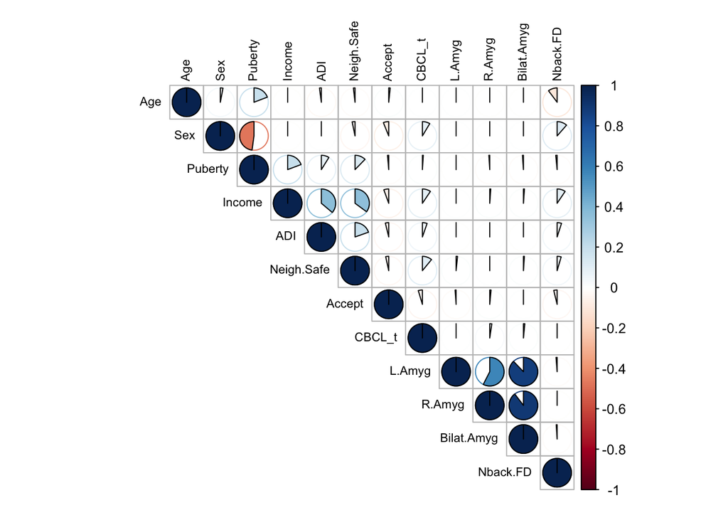

```r
library(corrplot)
corrplot(cor_table, type = "upper",
         method = "pie", #title = "Pairwise Pearson r among variables",
         tl.cex = 0.7, tl.col = 'black',
         mar=c(1, 1, 1, 1))
```

```r
# write.csv(cor_table, "~/Downloads/correlation_vars.csv")
```

# 7 Prep/Export: Mplus

# 8 Prep/Export: Mplus

## 8.1 Wide form, Var select

```r
# BL and Y1 rather than 1 and 2 so that it was clear when it was combined with the variable names
Mplus_data = abcd_mplus %>%
  mutate(Event_short = if_else(Event == "Baseline", "BL", "Y1"))

# dummy code scan variable
Mplus_data = Mplus_data %>%
  mutate(Scan1 = if_else(scanner_type == 1, 1, 0),
         Scan2 = if_else(scanner_type == 2, 1, 0))

vars = c("Age","Event","Sex_M1F0","Race","Inc_BL","Puberty","ADI","CBCL_t",
         "Neigh_safe","Par_Accept","L_Amyg","R_Amyg","Bilat_Amyg",
         "Family", "Inc_BL_r","Neigh_safe_r",
         "scanner_type","Scan1","Scan2","ABCDsite")
# wide format
Mplus_data_wide <- as.data.frame(pivot_wider(data = Mplus_data,
                               id_cols = ID,
                               names_from = Event_short,
                               names_sep = "_",
                               values_from = vars )
                                )
```

## 8.2 Marking NA values

Replacing `NA` with `99999`

```r
# Removing non-existent columns (e.g. L_Amyg_Y1) and cleaning up variable names
all_na <- function(x) any(!is.na(x))

Mplus_data_wide = Mplus_data_wide %>%
  select_if(all_na) %>%
  rename(Inc_BL = Inc_BL_BL,
         Inc_BL_r = Inc_BL_r_BL,
         Family = Family_BL)


Mplus_data_wide[Mplus_data_wide=='NULL'] <- 99999
Mplus_data_wide[is.na(Mplus_data_wide)] = 99999
```

## 8.3 Saving `.dat` file

```r
library(multiplex)
library(MplusAutomation)

Mplus_wide_final <- Mplus_data_wide %>%
  filter(Event_BL =="Baseline") %>%
  select(-Event_BL, -Event_Y1)



write.dat(Mplus_wide_final, "~/Desktop/UM/4_ABCD/3_Projects/1_Cortex_sub/Stage2/data/Cortex_Mplus_2020_12_09_WIDE.dat")
colnames(Mplus_wide_final)
```